# Regional US Patterns

June 10, 2020

I have added a reference line to the state plots of the estimated daily Covid-19 deaths per day relative to the average US deaths per day. The average deaths per year in the US (all age groups) is roughly 10,000 per million (roughly 1% of population per year), obviously it higher in some states than others but for now I am not downloading the state by state info on that.

That translates to `10000 x pop size in millions / 365` deaths per day. I can translate new cases per day into future deaths per day using CFR. I put a reference line of 5% of normal deaths per day. Note Covid-19 deaths are heavily skewed to those over 70 and deaths rates for that age group is 2-4 times higher than the all-age groups rate. However, the denominator (millions of people age 70+) is even smaller, so actually if I tranlated this just to focus on those age 70+, it would look even worse. Meaning the Covid-19 death rate relative to normal death rate would be higher.

# Summary

The east coast is still declining and no sign of another wave starting. Other earlier hotspots (like MN) are also on the decline. Cases are starting to rise in areas that were previously much lower. Based on the news reports, it sounds like once the new cases per million get up near 150 and the Covid daily death rate at ca 25% of the normal death rate, it starts taxing the health care system. That is what is happening in Arizona now and they have sent out an emergency alert to the hospitals to prepare. This doesn’t mean that the system is overwhelmed, but that the cases are starting to push pressure on the system and hospitals need to get ready for a wave coming through.

The states where this is happening now are Arizona and North Carolina. Many other states have increasing cases, but the new cases per million are still well below 100 per million and it seems like the health care system can handle that. Note, the death is ca 1-10% (depending on state) so every 100 new cases in a state, that will translate to 1-10 future deaths. So though the health care system can handle the load, remember that there is no cure and there is a high death rate for those who are sick enough to go get tested. Most people don’t get that sick but the “new cases” that I am tracking are those who are pretty sick and they have a high death rate.

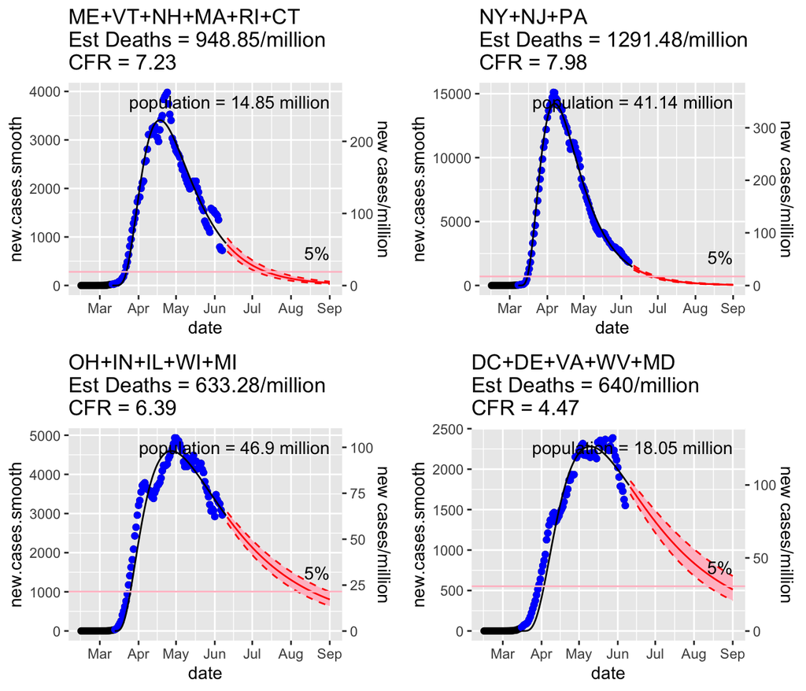

Two weeks ago, I was watching South Dakota, Mississippi, Minnesota and Illinois. The 3 midwest states are trending downward. There is no sign of an uptick in cases in MN from the protests (nor in NYC, PA, DC). Maybe masks and being outdoors drastically reduced transmission? There is an uptick in MI, but it looks like it might be a one day increase such as happens when a bunch of back-logged cases are released. We’ll know in a few days. Something is odd in SD. The death rate is very high 17 CFR which is 3-4x higher than other states.

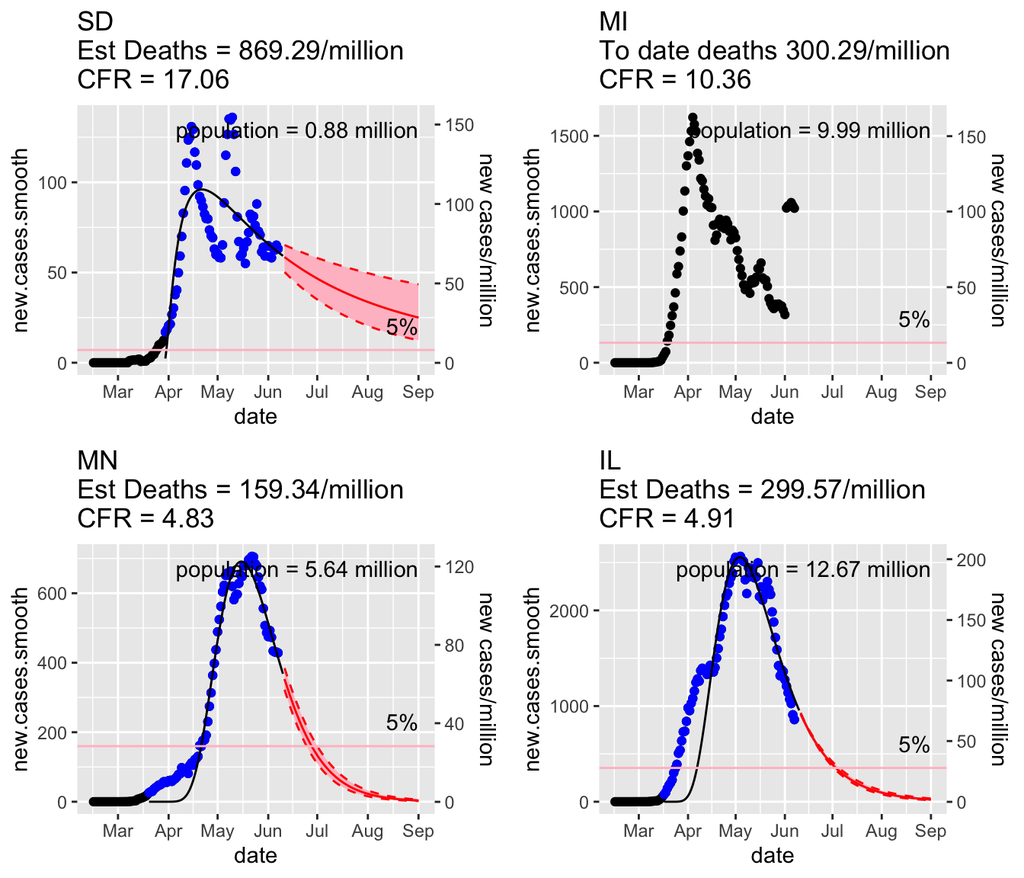

There is still a lot of discussion and worry about the southern states, and new cases are still high and increasing in Florida. However overall the south is not seeing a surge in cases like we saw in the northeast in the early part of the epidemic..

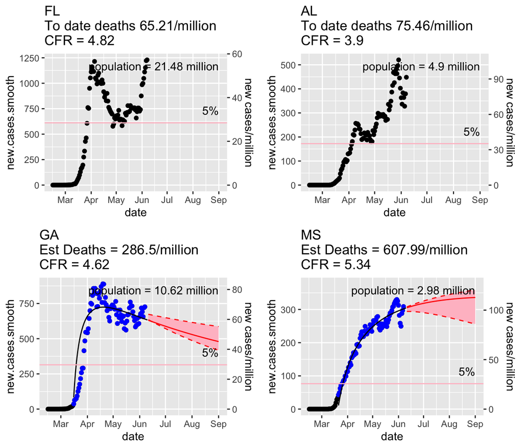

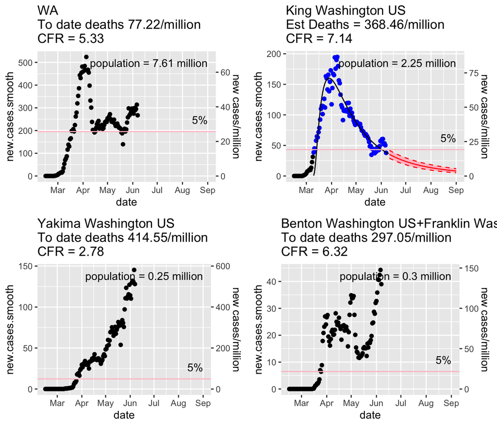

## Regional trends

Note: scroll down to the bottom of this page to see state by state data: https://eeholmes.github.io/CoV19/Forecasts.html

Take home is that across the US, the new case curves (7-day average) continue to show a downward trend at the regional level across the northeast, even as states start to open up and despite the on-going protests. However in the southwest, the cases are increasing and at least one state (Arizona) is getting above the critical 150 new cases per million level.

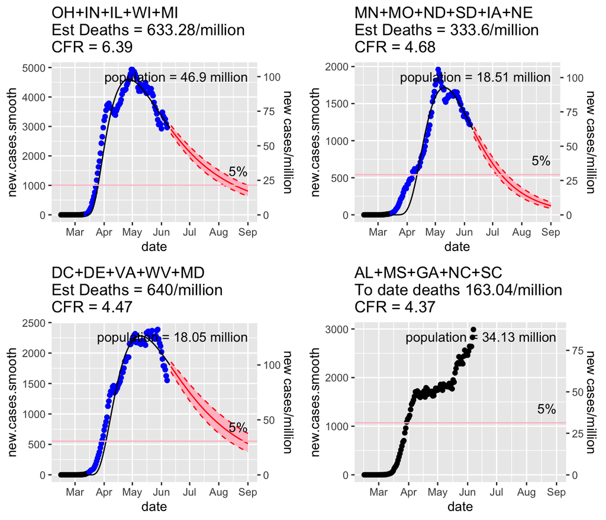

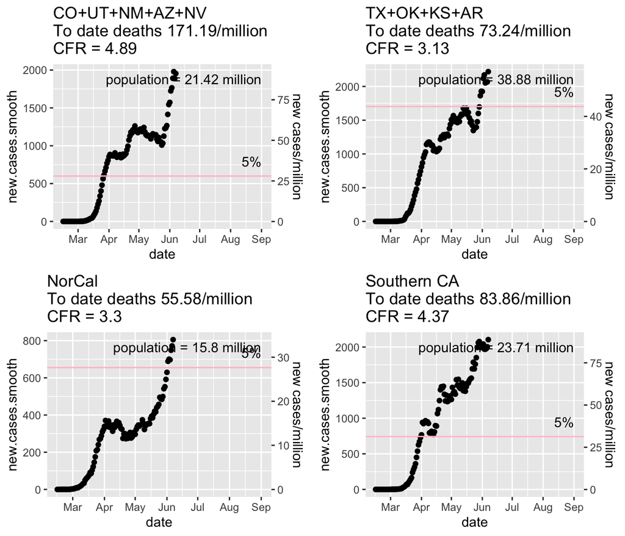

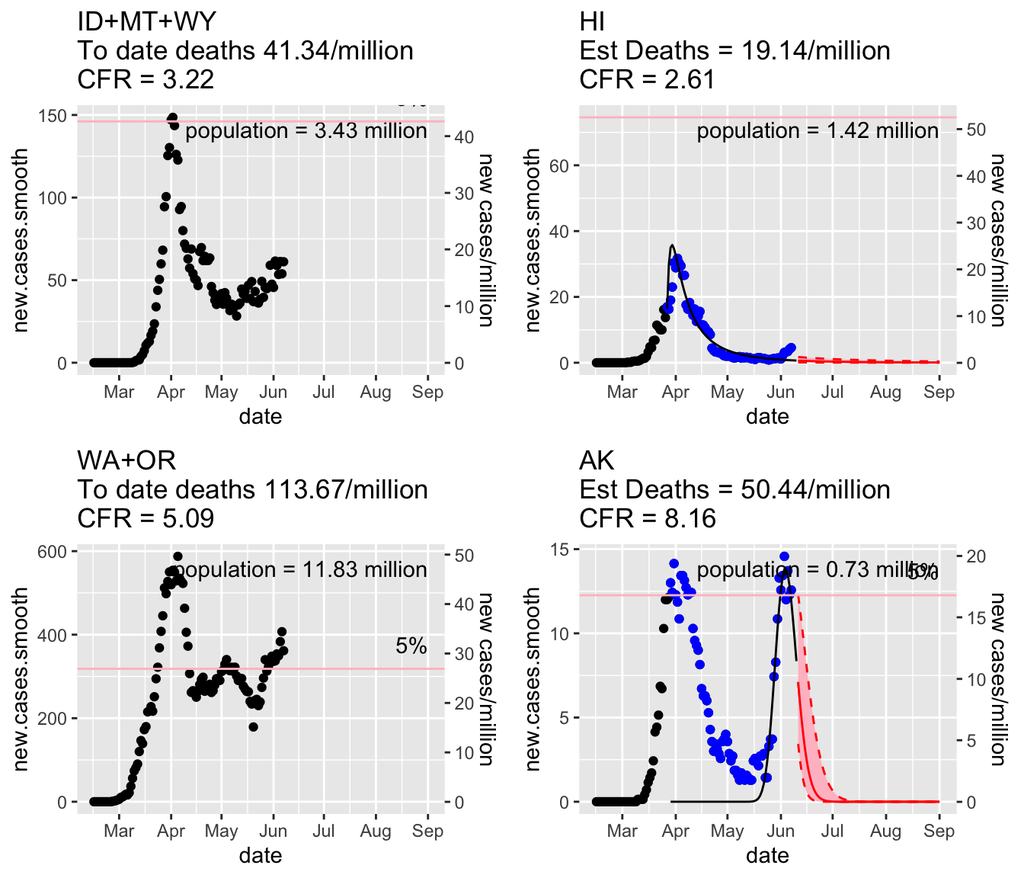